# Tugas-Pertemuan-7

Afiq Dzakwan Anasti - G1401231058

2025-10-03

# 1 Import Libraries & Data

```r
library(TSA)
library(TTR)
library(MASS)
library(aTSA)
library(readxl)
library(ggplot2)
library(tsibble)
library(tseries)
library(forecast)
library(graphics)
```

```r
dt <- read_excel("C:\\Users\\afiqd\\Downloads\\Sem 5\\MPDW\\praktikum 2\\TSLA_weekly.xlsx", sheet = "afiq")
head(dt)
```

```
## # A tibble: 6 × 2
##   date                close
##   <dttm>              <dbl>
## 1 2010-06-28 00:00:00  1.28
## 2 2010-07-05 00:00:00  1.16
## 3 2010-07-12 00:00:00  1.38
## 4 2010-07-19 00:00:00  1.42
## 5 2010-07-26 00:00:00  1.33
## 6 2010-08-02 00:00:00  1.31
```

```r
dt1 <- ts(dt$close)

mean1 <- mean(dt1)
var1 <- var(dt1)

mean1
```

```
## [1] 4.065162
```

```r
var1
```

```
## [1] 15.67285
```

# 2 Eksplorasi Data

## 2.1 Plot Data Penuh

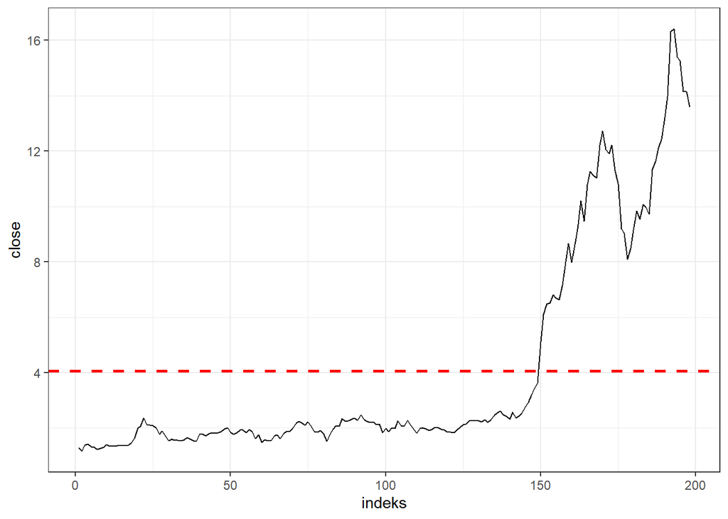

```r
plot1 <- dt1 |> as_tsibble() |>
  ggplot(aes(x = index, y = value)) + geom_line() + theme_bw() +
  geom_hline(yintercept = mean1, color = "red", linetype = "dashed", size = 1) +
  xlab("indeks") + ylab("close")

plot1
```

Plot deret waktu di atas menunjukkan bahwa data tidak stasioner dalam rataan, ditandai dengan pola trend yang fluktuatif dan tidak berada pada garis tengah mean (4.065) serta tidak stasioner dalam ragam, ditandai dengan lebar pita yang berbeda.

```r
dt1
```

```
## Time Series:
## Start = 1
## End = 198
## Frequency = 1
##   [1]  1.280000  1.160000  1.376000  1.419333  1.329333  1.306000  1.221333
##   [8]  1.273333  1.313333  1.403333  1.344667  1.348667  1.340000  1.373333
##  [15]  1.362000  1.369333  1.381333  1.456000  1.629333  1.989333  2.066000
##  [22]  2.354667  2.099333  2.101333  2.090667  2.006000  1.775333  1.882667
##  [29]  1.716667  1.536000  1.600667  1.564000  1.550000  1.545333  1.574000
##  [36]  1.663333  1.604667  1.530667  1.516667  1.777333  1.766000  1.705333
##  [43]  1.782667  1.840000  1.808000  1.836667  1.864667  1.970000  2.008667
##  [50]  1.857333  1.766667  1.838000  1.934667  1.920667  1.838667  1.952667
##  [57]  1.878000  1.616000  1.754000  1.486667  1.582000  1.538000  1.531333
##  [64]  1.720000  1.758667  1.626000  1.799333  1.870000  1.868667  1.991333
##  [71]  2.154000  2.242667  2.173333  2.110667  2.220000  2.069333  1.866667
```

[output cut: 18 more lines]

terdapat tren kenaikan yang cukup drastis dari data indeks 150 ke atas

Berdasarkan plot data deret waktu, terlihat bahwa data konstan di awal lalu disekitar indeks 150an mulai mengalami tren signifikan. Berdasarkan pola data, pembagian data latih dan data uji ditetapkan dengan proporsi 80:20 sehingga data latih bisa memuat pola ketika inisiasi tren.

## 2.2 Plot Data Latih

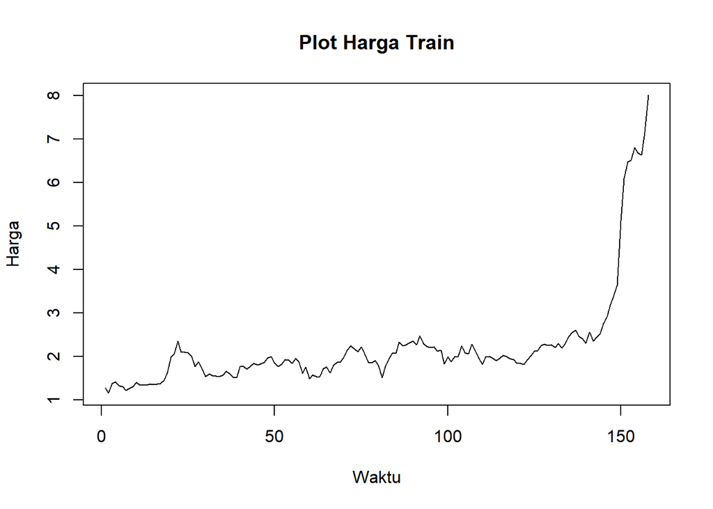

```r
dttrain <- dt1[1:158]
train.ts <- ts(dttrain)
plot.ts(train.ts, lty=1, xlab="Waktu", ylab="Harga", main="Plot Harga Train")
```

Berdasarkan plot data deret waktu pada data latih, terlihat bahwa data cenderung memiliki trend fluktuatif dan tidak bergerak pada nilai tengah tertentu. Hal ini mengindikasikan bahwa data tidak stasioner dalam rataan.

## 2.3 Plot Data Uji

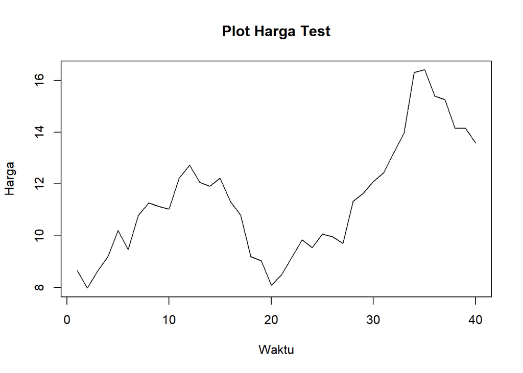

```r
dttest<-dt1[159:198]
test.ts<-ts(dttest)
plot.ts(test.ts, lty=1, xlab="Waktu", ylab="Harga", main="Plot Harga Test")
```

# 3 Uji Stasioneritas Data

## 3.1 Plot ACF

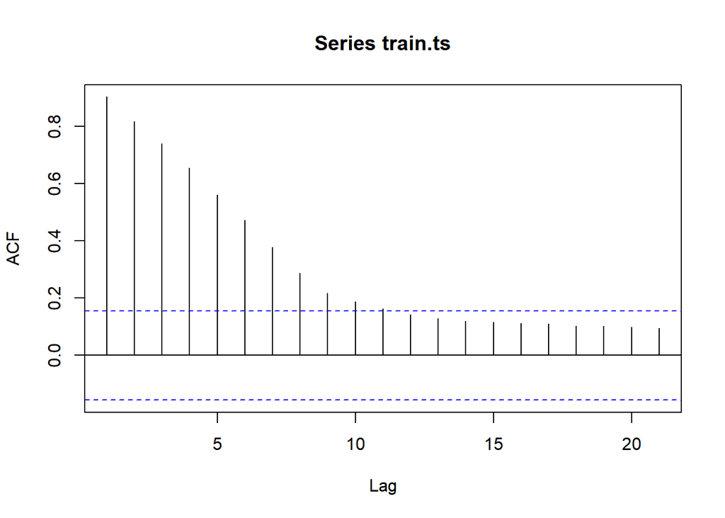

```r
acf(train.ts)
```

Berdasarkan plot ACF, terlihat bahwa plot ACF data menurun secara perlahan (*tails of slowly*). Hal ini juga menjadi indikasi bahwa data tidak stasioner dalam rataan

## 3.2 Uji ADF

```r
tseries::adf.test(train.ts)
```

```
##
##  Augmented Dickey-Fuller Test
##
## data:  train.ts
## Dickey-Fuller = 3.0806, Lag order = 5, p-value = 0.99
## alternative hypothesis: stationary
```

$H_0$ : Data tidak stasioner dalam rataan

$H_1$ : Data stasioner dalam rataan

Berdasarkan uji ADF tersebut, didapat *p-value* sebesar 0.99 yang lebih besar dari taraf nyata 5% sehingga tak tolak $H_0$ dan menandakan bahwa data tidak stasioner dalam rataan. Hal ini sesuai dengan hasil eksplorasi menggunakan plot time series dan plot ACF, sehingga ketidakstasioneran model kedepannya harus ditangani

## 3.3 Plot Box-Cox

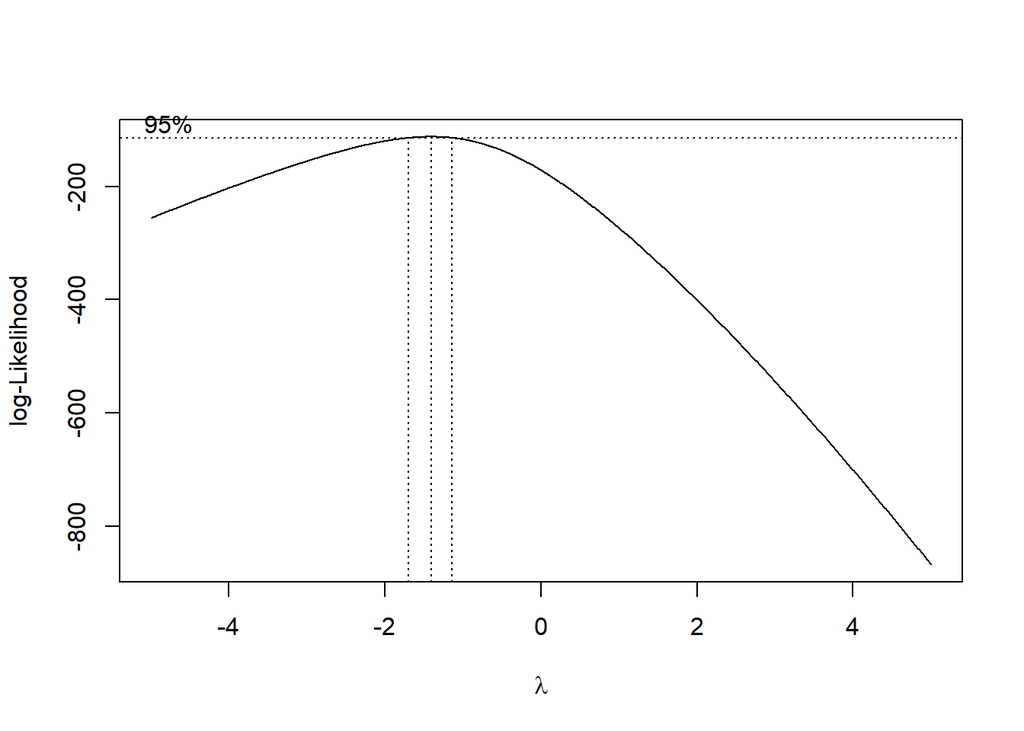

```r
index <- seq(1:158)
bc = boxcox(train.ts~index, lambda = seq(-5,5,by=0.01))
```

```r
#Nilai Rounded Lambda
lambda <- bc$x[which.max(bc$y)]
lambda
```

```
## [1] -1.41
```

```r
#SK
bc$x[bc$y > max(bc$y) - 1/2 * qchisq(.95,1)]
```

```
##  [1] -1.69 -1.68 -1.67 -1.66 -1.65 -1.64 -1.63 -1.62 -1.61 -1.60 -1.59 -1.58
## [13] -1.57 -1.56 -1.55 -1.54 -1.53 -1.52 -1.51 -1.50 -1.49 -1.48 -1.47 -1.46
## [25] -1.45 -1.44 -1.43 -1.42 -1.41 -1.40 -1.39 -1.38 -1.37 -1.36 -1.35 -1.34
## [37] -1.33 -1.32 -1.31 -1.30 -1.29 -1.28 -1.27 -1.26 -1.25 -1.24 -1.23 -1.22
## [49] -1.21 -1.20 -1.19 -1.18 -1.17 -1.16 -1.15
```

# 4 Penanganan Ketakstasioneran Data

## 4.1 Transformasi Box-Cox

```r
train.ts <- BoxCox(train.ts, lambda = "auto")

lambda_terpilih <- attr(train.ts, "lambda")
print(paste("Lambda optimal yang dipilih:", lambda_terpilih))
```

```
## [1] "Lambda optimal yang dipilih: -0.56625024323344"
```

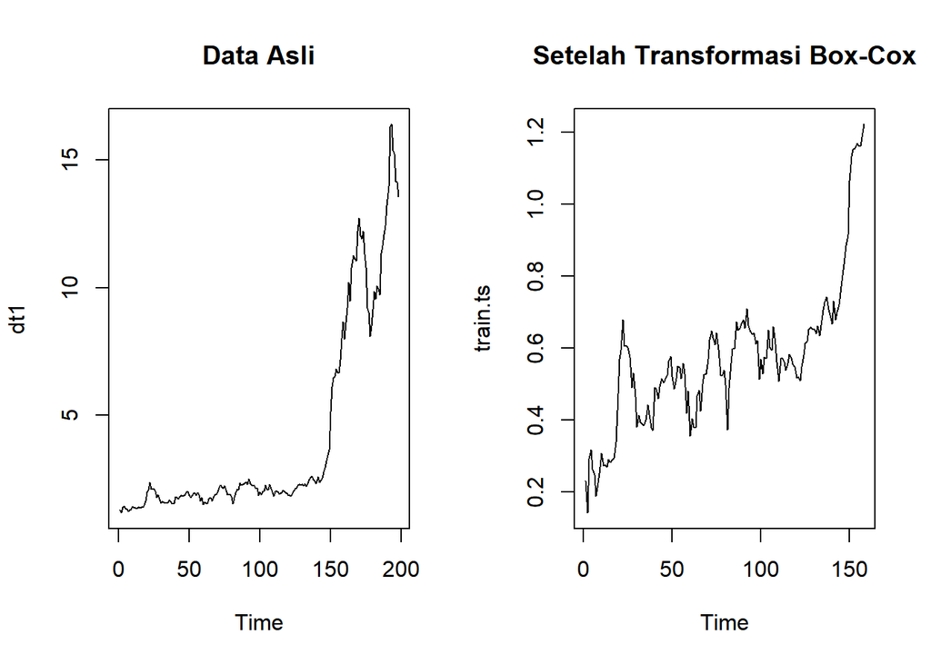

```r
# Plot perbandingan
par(mfrow=c(1,2))
plot(dt1, type="l", main="Data Asli")
plot(train.ts, type="l", main="Setelah Transformasi Box-Cox")
```

## 4.2 differencing

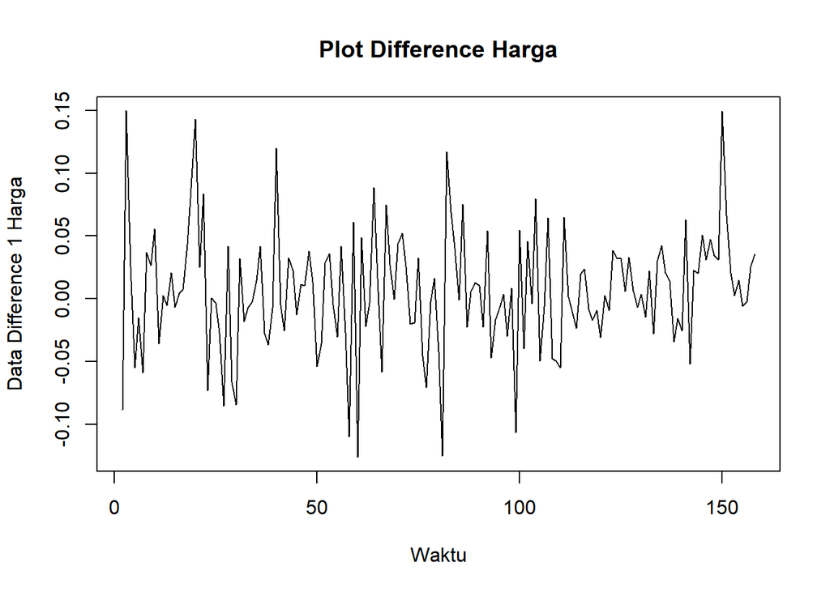

```r
train.diff <- diff(train.ts,differences = 1)
plot.ts(train.diff, lty=1, xlab="Waktu", ylab="Data Difference 1 Harga", main="Plot Difference Harga")
```

Berdasarkan plot data deret waktu, terlihat bahwa data sudah stasioner dalam rataan dan ragam, ditandai dengan data bergerak pada nilai tengah tertentu (tidak terdapat trend ataupun musiman pada data).

## 4.3 Plot ACF

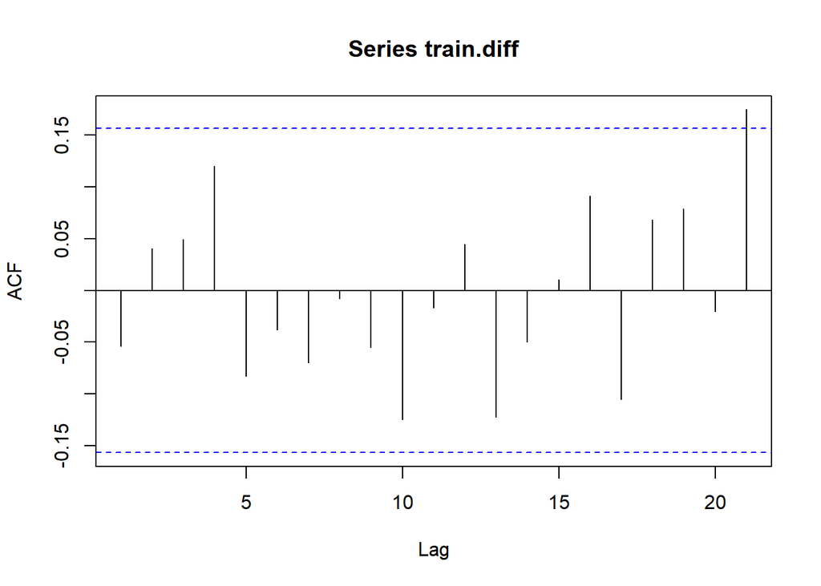

```r
acf(train.diff)
```

Berdasarkan plot tersebut, terlihat bahwa plot ACF sudah tails off secara normal (tidak slowly). Hal ini menandakan data sudah stasioner dalam rataan dan ketidakstasioneran data telah berhasil tertangani.

## 4.4 Uji ADF

```r
tseries::adf.test(train.diff)
```

```
##
##  Augmented Dickey-Fuller Test
##
## data:  train.diff
## Dickey-Fuller = -5.0245, Lag order = 5, p-value = 0.01
## alternative hypothesis: stationary
```

$H_0$ : Data tidak stasioner dalam rataan

$H_1$ : Data stasioner dalam rataan

Berdasarkan uji ADF tersebut, didapat *p-value* sebesar 0.01 yang lebih kecil dari taraf nyata 5% sehingga tolak $H_0$ atau data stasioner dalam rataan. Hal ini sesuai dengan hasil eksplorasi menggunakan plot time series dan plot ACF, sehingga dalam hal ini ketidakstasioneran data sudah berhasil ditangani dan dapat dilanjutkan ke pemodelan

## 4.5 Plot Box-Cox

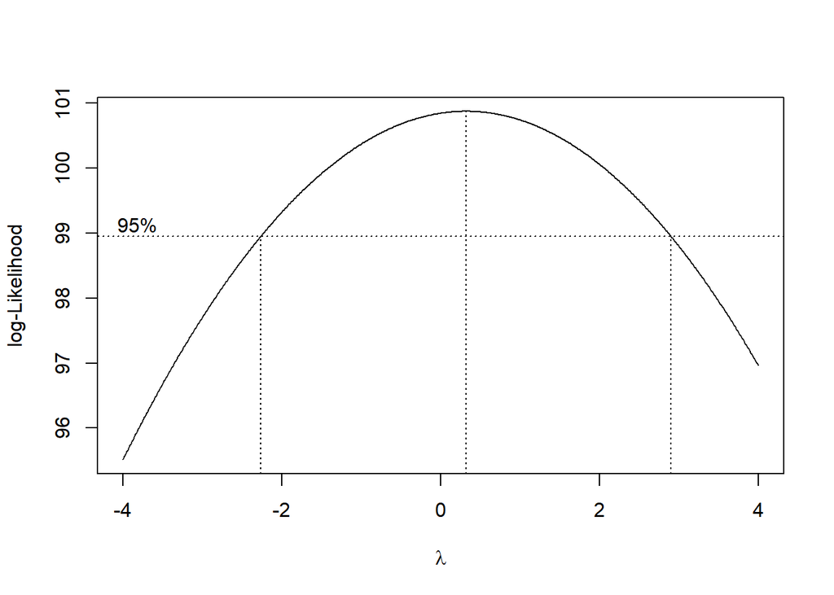

```r
index <- seq(1:length(train.diff))

# Uji Box-Cox
bc <- boxcox(
  train.diff - min(train.diff) + 1 ~ index,
  lambda = seq(-4, 4, by = 0.01)
)
```

```r
# Nilai lambda optimum (dibulatkan)
lambda <- bc$x[which.max(bc$y)]
lambda
```

```
## [1] 0.32
```

```r
# Selang kepercayaan 95% untuk lambda
ci_lambda <- bc$x[bc$y > max(bc$y) - 0.5 * qchisq(0.95, 1)]

# Batas bawah dan batas atas
ci_lower <- min(ci_lambda)
ci_upper <- max(ci_lambda)

c(Batas_Bawah = ci_lower, Batas_Atas = ci_upper)
```

```
## Batas_Bawah  Batas_Atas
##       -2.26        2.89
```

# 5 Identifikasi Model

## 5.1 Plot ACF

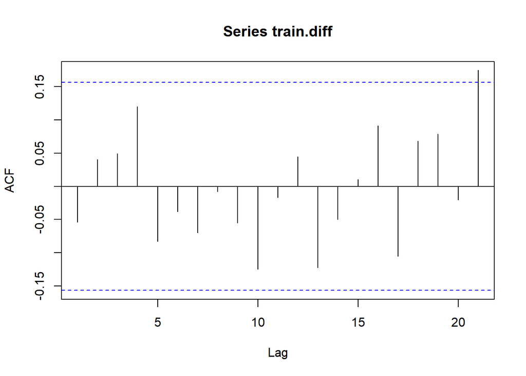

```r
acf(train.diff)
```

Berdasarkan plot tersebut, tidak dapat diidentifikasi kecendrungan tertentu.

## 5.2 Plot PACF

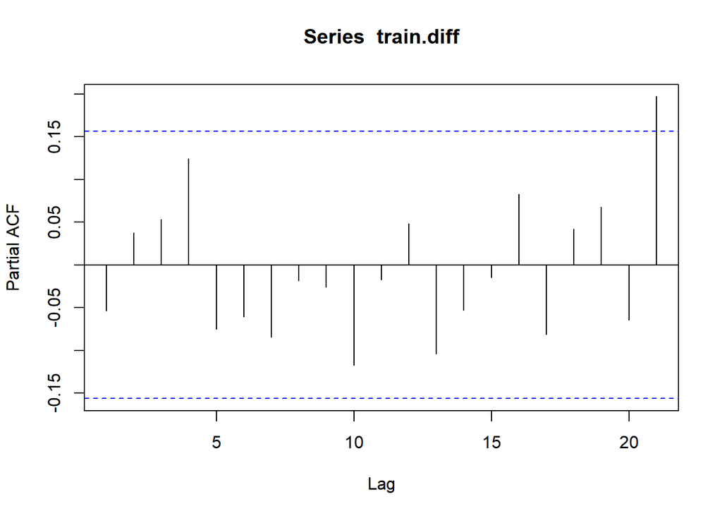

```r
pacf(train.diff)
```

Berdasarkan plot tersebut, tidak dapat diidentifikasi kecendrungan tertentu.

## 5.3 Plot EACF

```r
eacf(train.diff)
```

```
## AR/MA
##   0 1 2 3 4 5 6 7 8 9 10 11 12 13
## 0 o o o o o o o o o o o  o  o  o
## 1 x o o o o o o o o o o  o  o  o
## 2 x x o o o o o o o o o  o  o  o
## 3 x o x o o o o o o o o  o  o  o
## 4 x x x x o o o o o o o  o  o  o
## 5 x x x o o o o o o o o  o  o  o
## 6 x x x o o x o o o o o  o  o  o
## 7 x x x o o o o o o o o  o  o  o
```

Identifikasi model menggunakan plot EACF dilakukan dengan melihat ujung segitiga pada pola segitiga nol. Dalam hal ini model tentatif yang terbentuk adalah ARIMA(0,1,1), ARIMA(0,1,2), ARIMA(1,1,1), ARIMA(1,1,2), dan ARIMA(2,1,2).

# 6 Pendugaan Parameter Model Tentatif

## 6.1 ARIMA(0,1,1)

```r
model1.da=Arima(train.ts, order=c(0,1,1),method="ML")
summary(model1.da)
```

```
## Series: train.ts
## ARIMA(0,1,1)
##
## Coefficients:
##           ma1
##       -0.0313
## s.e.   0.0757
##
## sigma^2 = 0.002324:  log likelihood = 253.79
## AIC=-503.58   AICc=-503.51   BIC=-497.47
##
## Training set error measures:
##                       ME       RMSE        MAE       MPE     MAPE      MASE
## Training set 0.006474327 0.04790066 0.03594436 0.4070693 7.467248 0.9943603
##                     ACF1
## Training set -0.01962307
```

```r
lmtest::coeftest(model1.da)
```

```
##
## z test of coefficients:
##
##      Estimate Std. Error z value Pr(>|z|)
## ma1 -0.031268   0.075663 -0.4133   0.6794
```

## 6.2 ARIMA(0,1,2)

```r
model2.da=Arima(train.ts, order=c(0,1,2),method="ML")
summary(model2.da)
```

```
## Series: train.ts
## ARIMA(0,1,2)
##
## Coefficients:
##           ma1     ma2
##       -0.0432  0.0536
## s.e.   0.0827  0.0751
##
## sigma^2 = 0.002331:  log likelihood = 254.05
## AIC=-502.09   AICc=-501.94   BIC=-492.92
##
## Training set error measures:
##                       ME       RMSE        MAE       MPE     MAPE      MASE
## Training set 0.006224164 0.04782205 0.03595378 0.3797932 7.492723 0.9946211
##                      ACF1
## Training set -0.009879102
```

```r
lmtest::coeftest(model2.da)
```

```
##
## z test of coefficients:
##
##      Estimate Std. Error z value Pr(>|z|)
## ma1 -0.043217   0.082669 -0.5228   0.6011
## ma2  0.053573   0.075147  0.7129   0.4759
```

## 6.3 ARIMA(1,1,1)

```r
model3.da=Arima(train.ts, order=c(1,1,1),method="ML")
summary(model3.da)
```

```
## Series: train.ts
## ARIMA(1,1,1)
##
## Coefficients:
##           ar1     ma1
##       -0.8610  0.8198
## s.e.   0.1809  0.2020
##
## sigma^2 = 0.002326:  log likelihood = 254.22
## AIC=-502.43   AICc=-502.28   BIC=-493.26
##
## Training set error measures:
##                       ME       RMSE        MAE       MPE     MAPE      MASE
## Training set 0.006416403 0.04776862 0.03580602 0.3996032 7.456709 0.9905334
##                      ACF1
## Training set -0.005064876
```

```r
lmtest::coeftest(model3.da)
```

```
##
## z test of coefficients:
##
##     Estimate Std. Error z value  Pr(>|z|)
## ar1 -0.86096    0.18091 -4.7592 1.944e-06 ***
## ma1  0.81982    0.20196  4.0594 4.920e-05 ***
## ---
## Signif. codes:  0 '***' 0.001 '**' 0.01 '*' 0.05 '.' 0.1 ' ' 1
```

## 6.4 ARIMA(1,1,2)

```r
model4.da=Arima(train.ts, order=c(1,1,2),method="ML")
summary(model4.da)
```

```
## Series: train.ts
## ARIMA(1,1,2)
##
## Coefficients:
##         ar1      ma1     ma2
##       0.600  -0.6558  0.1292
## s.e.  0.256   0.2581  0.0923
##
## sigma^2 = 0.002325:  log likelihood = 254.74
## AIC=-501.48   AICc=-501.22   BIC=-489.26
##
## Training set error measures:
##                       ME      RMSE       MAE       MPE     MAPE      MASE
## Training set 0.005357589 0.0476063 0.0360215 0.2832535 7.542225 0.9964943
##                       ACF1
## Training set -0.0005742754
```

```r
lmtest::coeftest(model4.da)
```

```
##
## z test of coefficients:
##
##      Estimate Std. Error z value Pr(>|z|)
## ar1  0.600034   0.256044  2.3435  0.01910 *
## ma1 -0.655845   0.258054 -2.5415  0.01104 *
## ma2  0.129205   0.092254  1.4005  0.16136
## ---
## Signif. codes:  0 '***' 0.001 '**' 0.01 '*' 0.05 '.' 0.1 ' ' 1
```

## 6.5 ARIMA(2,1,2)

```r
model5.da=Arima(train.ts, order=c(2,1,2),method="ML")
summary(model5.da)
```

```
## Series: train.ts
## ARIMA(2,1,2)
##
## Coefficients:
```

```
##          ar1     ar2      ma1      ma2
##       0.1963  0.3325  -0.2232  -0.2429
## s.e.     NaN     NaN      NaN      NaN
##
## sigma^2 = 0.002352:  log likelihood = 254.37
## AIC=-498.73   AICc=-498.34   BIC=-483.45
##
## Training set error measures:
##                       ME       RMSE        MAE       MPE     MAPE      MASE
## Training set 0.005594831 0.04772282 0.03589383 0.3105581 7.503729 0.9929627
##                     ACF1
## Training set -0.02443889
```

```r
lmtest::coeftest(model5.da)
```

```
##
## z test of coefficients:
##
##     Estimate Std. Error z value Pr(>|z|)
## ar1  0.19628        NaN     NaN      NaN
## ar2  0.33251        NaN     NaN      NaN
## ma1 -0.22323        NaN     NaN      NaN
## ma2 -0.24293        NaN     NaN      NaN
```

```r
model_tentatif <- data.frame(
  Model = c("ARIMA(0,1,1)",
            "ARIMA(0,1,2)",
            "ARIMA(1,1,1)",
            "ARIMA(1,1,2)",
            "ARIMA(2,1,2)"),
  AIC   = c(AIC(model1.da),
            AIC(model2.da),
            AIC(model3.da),
            AIC(model4.da),
            AIC(model5.da)),
  BIC   = c(BIC(model1.da),
            BIC(model2.da),
            BIC(model3.da),
            BIC(model4.da),
            BIC(model5.da))
  )

model_tentatif
```

```
##          Model       AIC       BIC
## 1 ARIMA(0,1,1) -503.5841 -497.4716
## 2 ARIMA(0,1,2) -502.0933 -492.9246
## 3 ARIMA(1,1,1) -502.4320 -493.2633
## 4 ARIMA(1,1,2) -501.4815 -489.2565
## 5 ARIMA(2,1,2) -498.7339 -483.4527
```

Berdasarkan pendugaan parameter di atas, nilai AIC terkecil dimiliki oleh model ARIMA(0,1,1), namun parameter model ARIMA(0,1,1) tidak ada yang signifikan pada taraf nyata 10% sehingga model yang dipilih adalah model dengan ARIMA(1,1,1).

# 7 Analisis Sisaan

## 7.1 Eksplorasi Sisaan

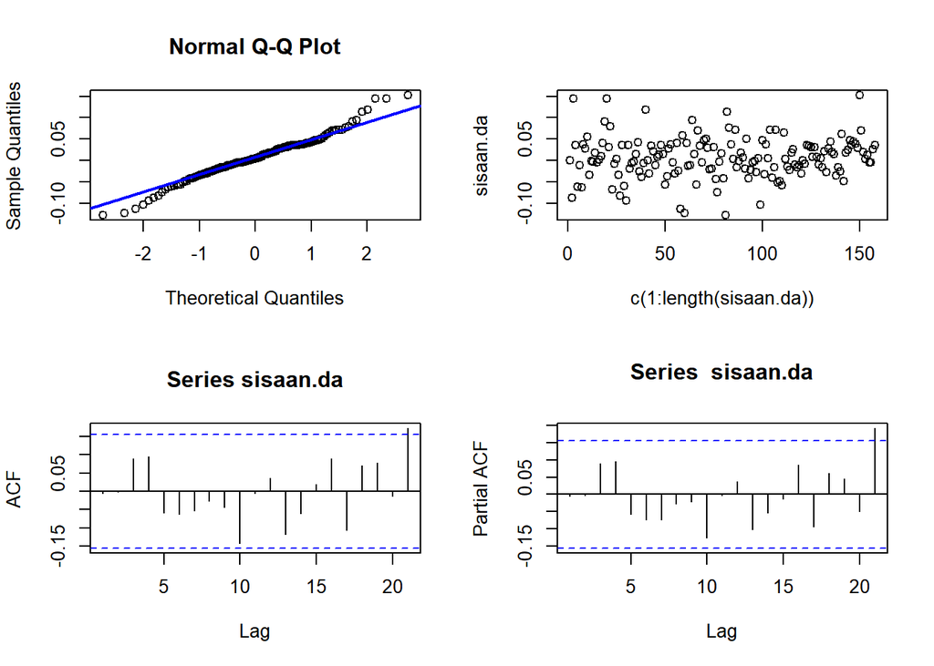

```r
sisaan.da <- model3.da$residuals
par(mfrow=c(2,2))
qqnorm(sisaan.da)
qqline(sisaan.da, col = "blue", lwd = 2)
plot(c(1:length(sisaan.da)),sisaan.da)
acf(sisaan.da)
pacf(sisaan.da)
```

```r
par(mfrow = c(1,1))
```

Berdasarkan plot kuantil-kuantil normal, secara eksplorasi ditunjukkan sisaan tidak menyebar normal ditandai dengan titik-titik yang cenderung tidak mengikuti garis $45^{\circ}$. Kemudian dapat dilihat juga lebar pita sisaan tidak sama menandakan bahwa sisaan memiliki ragam yang heterogen. Plot ACF dan PACF sisaan ARIMA(1,1,1) juga tidak signifikan pada 20 lag awal yang menandakan saling bebas. Kondisi ini akan diuji lebih lanjut dengan uji formal.

## 7.2 Uji Formal

### 7.2.1 Sisaan Menyebar Normal

```r
ks.test(sisaan.da,"pnorm")  #tak tolak H0 > sisaan menyebar normal
```

```
##
##  Asymptotic one-sample Kolmogorov-Smirnov test
##
## data:  sisaan.da
## D = 0.44925, p-value < 2.2e-16
## alternative hypothesis: two-sided
```

$H_0$ : Sisaan menyebar normal

$H_1$ : Sisaan tidak menyebar normal

Berdasarkan uji KS tersebut, didapat *p-value* < 2.2e-16 yang kurang dari taraf nyata 5% sehingga tolak $H_0$ dan menandakan bahwa sisaan tidak menyebar normal. Hal ini sesuai dengan hasil eksplorasi menggunakan plot kuantil-kuantil normal.

### 7.2.2 Autokorelasi

```r
Box.test(sisaan.da, type = "Ljung")  #tak tolak H0 > sisaan saling bebas
```

```
##
##  Box-Ljung test
##
## data:  sisaan.da
## X-squared = 0.0041306, df = 1, p-value = 0.9488
```

$H_0$ : Sisaan saling bebas

$H_1$ : Sisaan tidak tidak saling bebas

Berdasarkan uji Ljung-Box tersebut, didapat *p-value* sebesar 0.9488 yang lebih besar dari taraf nyata 5% sehingga tak tolak $H_0$ dan menandakan bahwa sisaan saling bebas.

### 7.2.3 Homogenitas Ragam

```r
Box.test((sisaan.da)^2, type = "Ljung")  #tak tolak H0 > sisaan homogen
```

```
##
##  Box-Ljung test
##
## data:  (sisaan.da)^2
## X-squared = 5.0413, df = 1, p-value = 0.02475
```

$H_0$ : Ragam sisaan homogen

$H_1$ : Ragam sisaan tidak homogen

Berdasarkan uji Ljung-Box terhadap sisaan kuadrat tersebut, didapat *p-value* sebesar 0.02475 yang lebih kecil dari taraf nyata 5% sehingga tolak $H_0$ dan menandakan bahwa ragam sisaan tidak homogen.

### 7.2.4 Nilai Tengah Sisaan

```r
t.test(sisaan.da, mu = 0, conf.level = 0.95)  #tak tolak h0 > nilai tengah sisaan sama dengan 0
```

```
##
##  One Sample t-test
##
## data:  sisaan.da
## t = 1.6984, df = 157, p-value = 0.0914
## alternative hypothesis: true mean is not equal to 0
## 95 percent confidence interval:
##  -0.001045471  0.013878278
## sample estimates:
##   mean of x
## 0.006416403
```

$H_0$ : nilai tengah sisaan sama dengan 0

$H_1$ : nilai tengah sisaan tidak sama dengan 0

Berdasarkan uji-ttersebut, didapat *p-value* sebesar 0.0914 yang lebih besar dari taraf nyata 5% sehingga tak tolak $H_0$ dan menandakan bahwa nilai tengah sisaan sama dengan nol.

# 8 Overfitting

Hasil model ARIMA(1,1,1) kemudian dilakukan pemeriksaan pada model overfittingnya, yaitu ARIMA(1,1,2) dan ARIMA(2,1,1). Karena model ARIMA(1,1,2) telah diduga sebelumnya dan menghasilkan model yang tidak lebih baik, maka selanjutnya overfitting hanya dilakukan pada model ARIMA(2,1,1).

```r
model7.da=Arima(train.ts, order=c(2,1,1),method="ML")
summary(model7.da)
```

```
## Series: train.ts
## ARIMA(2,1,1)
##
## Coefficients:
##          ar1     ar2      ma1
##       0.4994  0.1036  -0.5394
## s.e.  0.3140  0.0822   0.3062
##
## sigma^2 = 0.002331:  log likelihood = 254.55
## AIC=-501.09   AICc=-500.83   BIC=-488.87
##
## Training set error measures:
##                       ME       RMSE        MAE       MPE     MAPE      MASE
## Training set 0.005465907 0.04766746 0.03597723 0.2957235 7.523422 0.9952697
##                     ACF1
## Training set -0.01424885
```

```r
lmtest::coeftest(model7.da)
```

```
##
## z test of coefficients:
##
##      Estimate Std. Error z value Pr(>|z|)
## ar1  0.499439   0.314007  1.5905  0.11171
## ar2  0.103605   0.082218  1.2601  0.20762
## ma1 -0.539364   0.306221 -1.7614  0.07818 .
## ---
## Signif. codes:  0 '***' 0.001 '**' 0.01 '*' 0.05 '.' 0.1 ' ' 1
```

Hasil menunjukkan bahwa model tidak signifikan pada ar1, ar2, dan ma1 pada taraf nyata 5% serta memiliki nilai AIC yang lebih besar. Sehingga model ARIMA(1,1,1) tetap dipilih sebagai model akhir.

# 9 Peramalan

```r
#---FORECAST---#
ramalan.da <- forecast::forecast(model3.da, h = 52)
ramalan.da
```

```
##     Point Forecast     Lo 80    Hi 80     Lo 95    Hi 95
## 159       1.220952 1.1591440 1.282759 1.1264251 1.315478
## 160       1.222037 1.1364073 1.307667 1.0910777 1.352996
## 161       1.221102 1.1157031 1.326502 1.0599080 1.382297
## 162       1.221907 1.1008390 1.342975 1.0367495 1.407065
## 163       1.221214 1.0855607 1.356868 1.0137500 1.428679
## 164       1.221811 1.0735634 1.370058 0.9950859 1.448536
## 165       1.221297 1.0609913 1.381603 0.9761305 1.466464
## 166       1.221739 1.0505862 1.392892 0.9599832 1.483495
## 167       1.221359 1.0397092 1.403008 0.9435497 1.499168
## 168       1.221686 1.0303573 1.413016 0.9290737 1.514299
## 169       1.221404 1.0206631 1.422145 0.9143971 1.528411
## 170       1.221647 1.0120801 1.431214 0.9011420 1.542152
## 171       1.221438 1.0032663 1.439610 0.8877731 1.555103
## 172       1.221618 0.9952810 1.447955 0.8754654 1.567771
```

[output cut: 38 more lines]

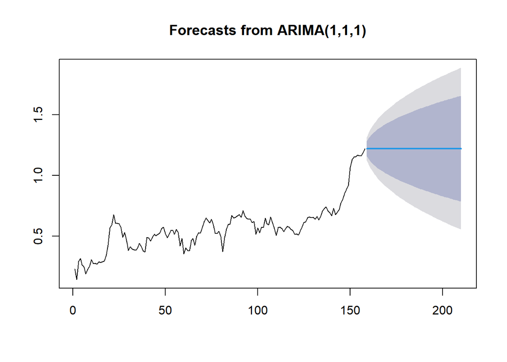

```r
data.ramalan.da <- ramalan.da$mean
plot(ramalan.da)
```

Berdasarkan hasil plot ramalan di atas, dapat dilihat bahwa ramalan ARIMA(1,1,1) cenderung stabil hingga akhir periode. Selanjutnya, dapat dicari nilai akurasi antara hasil ramalan dengan data uji sebagai berikut.

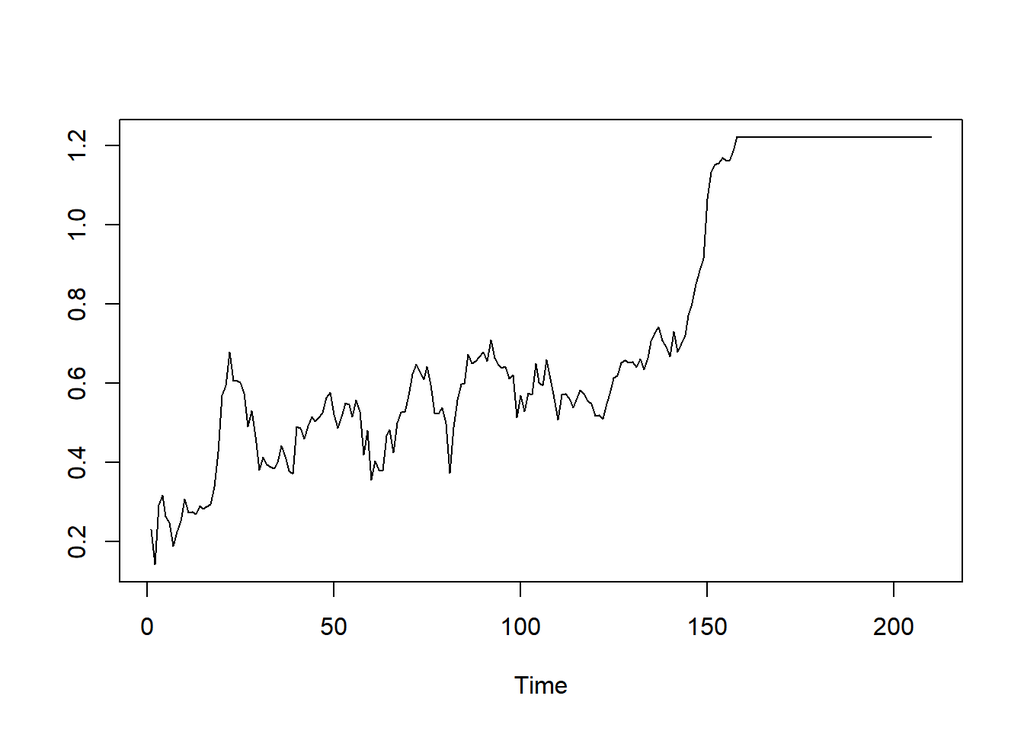

```r
pt_1 <- train.ts[158] #nilai akhir data latih
data.ramalan.da <- c(pt_1, data.ramalan.da)
hasil <- ts(data.ramalan.da, start=158)
ts.plot(train.ts,hasil)
```

```r
perbandingan.da<-matrix(data=c(head(test.ts, n=40), hasil[-1]),
                     nrow = 40, ncol = 2)
colnames(perbandingan.da)<-c("Aktual","Hasil Forecast")
perbandingan.da
```

```
##          Aktual Hasil Forecast
##  [1,]  8.660000       1.220952
##  [2,]  7.978667       1.222037
##  [3,]  8.626000       1.221102
##  [4,]  9.200000       1.221907
##  [5,] 10.200000       1.221214
##  [6,]  9.466667       1.221811
##  [7,] 10.789333       1.221297
##  [8,] 11.266667       1.221739
##  [9,] 11.131333       1.221359
## [10,] 11.036000       1.221686
## [11,] 12.226000       1.221404
## [12,] 12.726667       1.221647
## [13,] 12.065333       1.221438
## [14,] 11.913333       1.221618
```

[output cut: 26 more lines]

```r
accuracy(ts(hasil[-1]), head(test.ts, n=40))
```

```
##                ME     RMSE      MAE      MPE     MAPE      ACF1 Theil's U
## Test set 10.14659 10.39101 10.14659 88.84789 88.84789 0.9061884  12.34056
```

Hasil peramalan dari model ARIMA(1,1,1) dapat dikatakan sangat buruk karena memiliki nilai MAPE lebih dari 10% bahkan hingga 88%.